# The Normal Distribution

Corinne Riddell (Instructor: Tomer Altman)

September 29, 2025

# Learning objectives for today

- Learn about the Normal distribution centered at $\mu$ with a standard deviation of $\sigma$
- Learn about the standard Normal distribution where $\mu=0$ and $\sigma=1$ and compute z-scores
- Calculate cumulative probabilities below or above a given value for any specified Normal distribution using R
- Perform simple calculations by hand (using the 68-95-99.7 rule)

# The Normal Distribution

- Here is the Normal distribution with mean of $0$ ($\mu$) and standard deviation of $1$ ($\sigma$).
- It is:
  - symmetric
  - centered at $\mu$

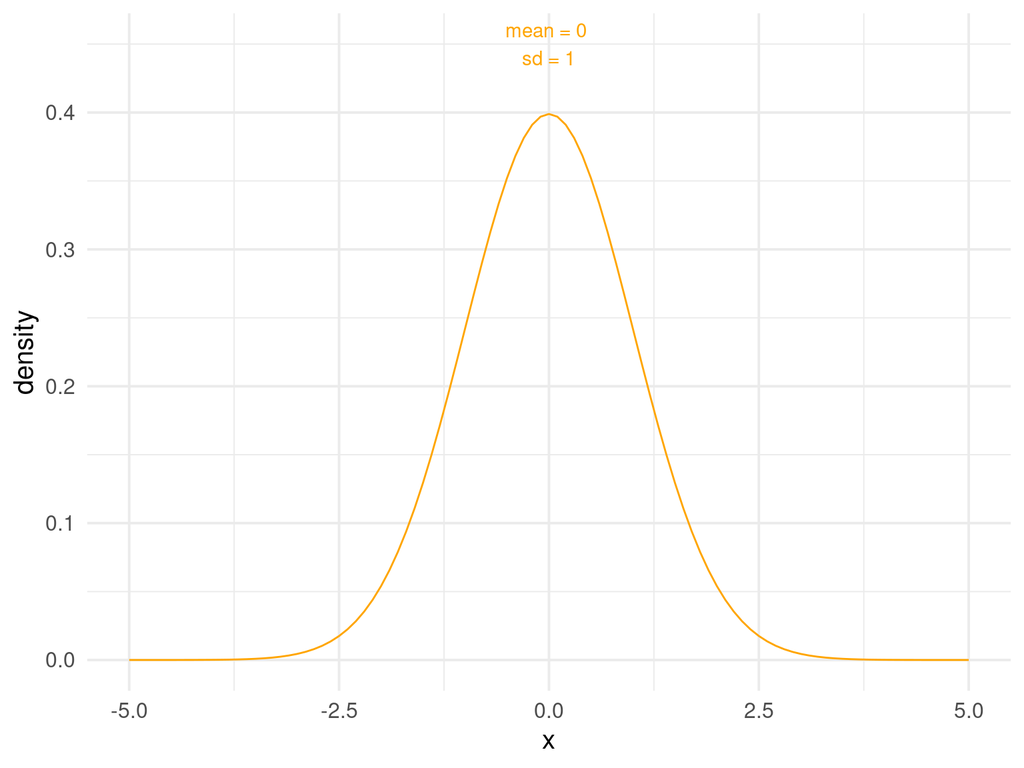

# The Normal Distribution

- Let’s add another Normal distribution, this one centered at $2$, with the same standard deviation

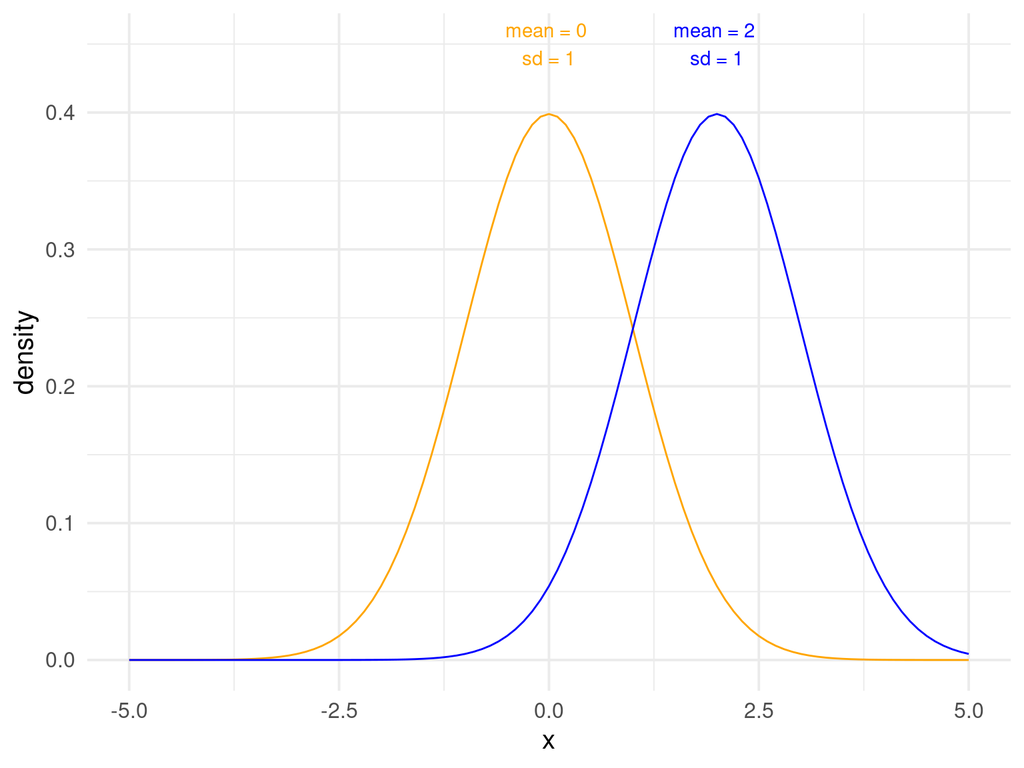

# The Normal Distribution

- Let’s add a third Normal distribution, this one centered at $-2$, with a standard deviation of $0.5$
- Notice how the distribution is narrowed (i.e., the spread is reduced)
- Why is the distribution “taller”?

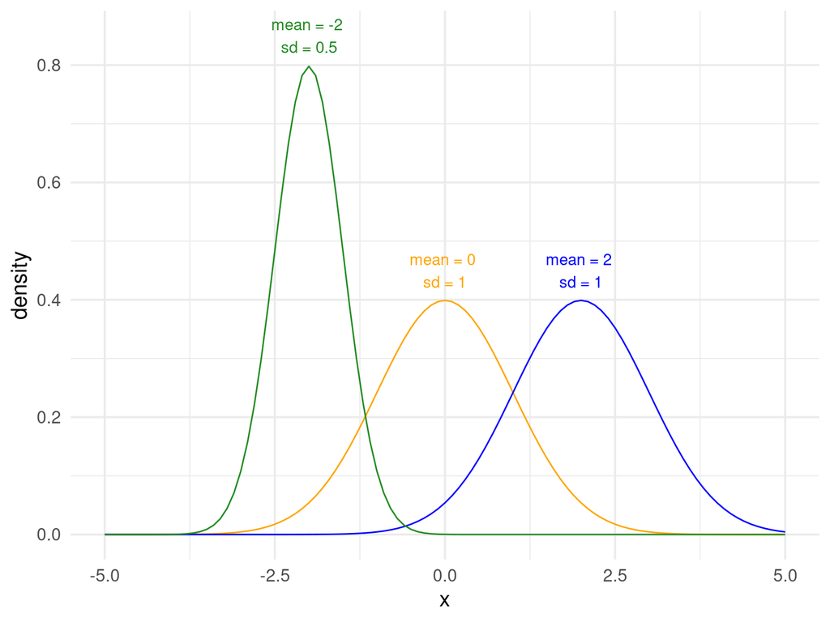

# The Normal Distribution

- Can you guess what a Normal distribution with $\mu=1$ and $\sigma=1.5$ would look like compared to the others?

# The Normal Distribution

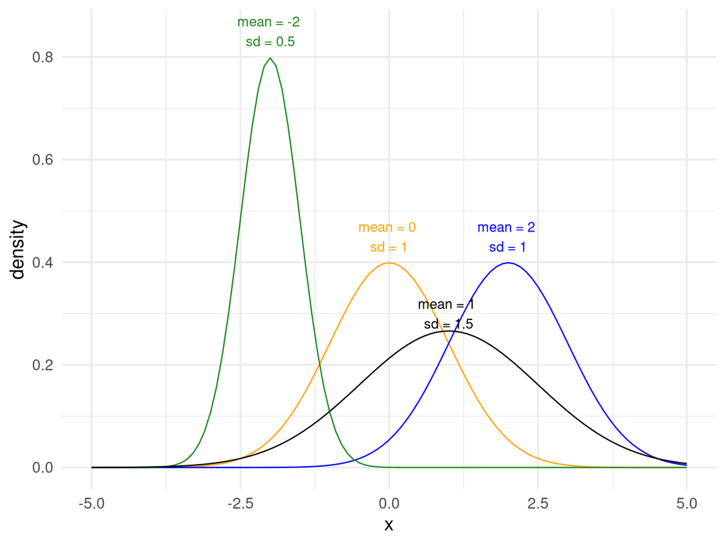

# Properties of the Normal distribution

- The density can be drawn by knowing just two parameters , the mean ($\mu$) and SD ($\sigma$): $f(x)=\phi(x)=\frac{1}{\sigma \sqrt{2\pi}}e^{-\frac{1}{2}\left(\frac{x-\mu}{\sigma}\right)^2}$
- The mean $\mu$ can be any value, positive or negative
- The standard deviation $\sigma$ must be a positive number
- The mean is equal to the median (both = $\mu$)
- The standard deviation captures the spread of the distribution
- The area under the Normal distribution is equal to 1 (i.e., it is a density function)

# The 68-95-99.7 rule for all Normal distributions

- Approximately 68% of the data fall within one standard deviation of the mean
- Approximately 95% of the data fall within two standard deviations of the mean
- Approximately 99.7% of the data fall within three standard deviations of the mean

Written probabilistically:

- $P(\mu - \sigma < X < \mu + \sigma) \approx 68\%$
- $P(\mu - 2\sigma < X < \mu + 2\sigma) \approx 95\%$
- $P(\mu - 3\sigma < X < \mu + 3\sigma) \approx 99.7\%$

# Calculations using the 68-95-99.7 rule

Example $11.1$ from Baldi & Moore on the heights of young women. The distribution of heights of young women is approximately Normal, with mean $\mu=64.5$ inches and standard deviation $\sigma=2.5$ inches.

We use notation to represent when a random variable follows a specific distribution. For example, letting $H$ represent the random variable for the height of a young woman, we can then write $H \sim N(64.5, 2.5)$, to say that the random variable $H$ follows a Normal distribution with a mean of $64.5$ and a standard deviation of $2.5$.

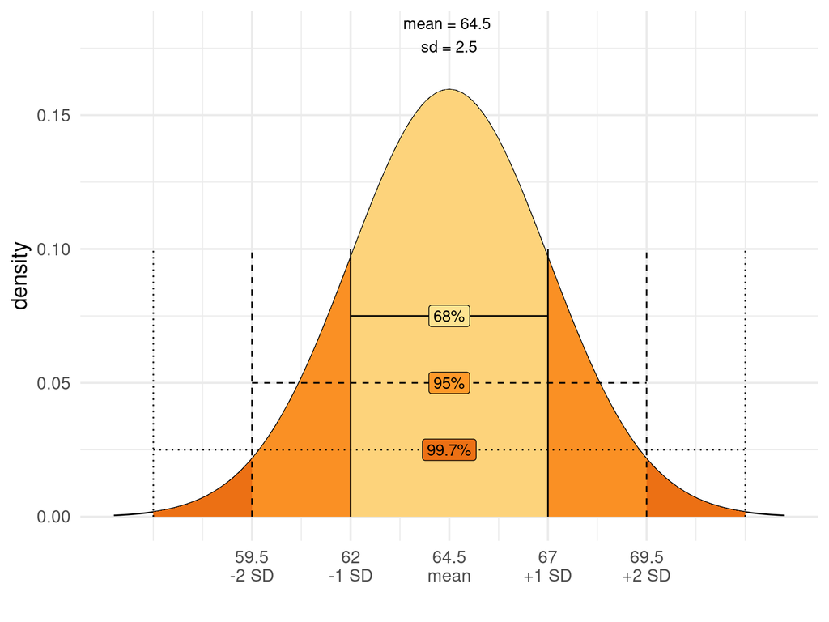

# Calculations using the 68-95-99.7 rule

- What calculations could you do with these data alone?
- $P(62 < H < 67)=?$
- $P(H > 62)=?$

# The standard Normal distribution

- The standard Normal distribution is the Normal distribution with $\mu = 0$ and $\sigma=1$.
- We write: $N(0,1)$ to denote this distribution
- $X \sim N(0,1)$, implies that the random variable X is Normally distributed.

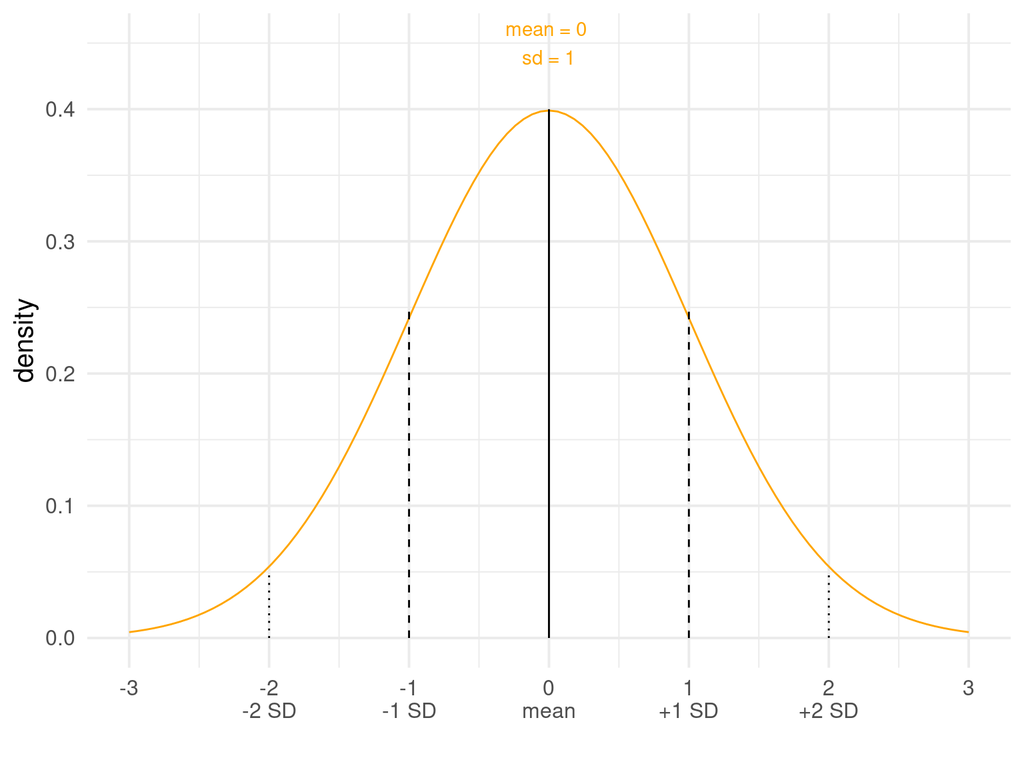

# Standardizing Normally distributed data

- Any random variable that follows a Normal distribution can be standardized. This means we can transform its distribution from being centred at $\mu$ with a standard deviation of $\sigma$ to another Normal distributuin with $\mu=0$ and standard deviation of $\sigma=1$
- If $x$ is an observation from a distribution that has a mean $\mu$ and a standard deviation $\sigma$, the standardized value of $x$ is calculated in the following way:

$$z = \frac{x-\mu}{\sigma}$$

- A standardized value is often called a **z-score**
- Interpretation: $z$ is the number of standard deviations that $x$ is above or below the mean of the data.
- We standardize values so that we can have this interpretation, which is agnostic to the underlying mean, standard deviation, and units of measure. Standardizing Normally-distributed data is a quick way to determine if a specific value is much higher or lower than the average value.

# Standardizing Normally distributed data

[figure not shown]

Source: [Intergrowth 21st Century](https://intergrowth21.tghn.org/)

# Standardizing Normally distributed data

In this image, the solid red line shows the average birthweight as a function of gestational age for boys and girls.

What is the approximate average birthweight in kilograms for a boy delivered at 33 weeks?

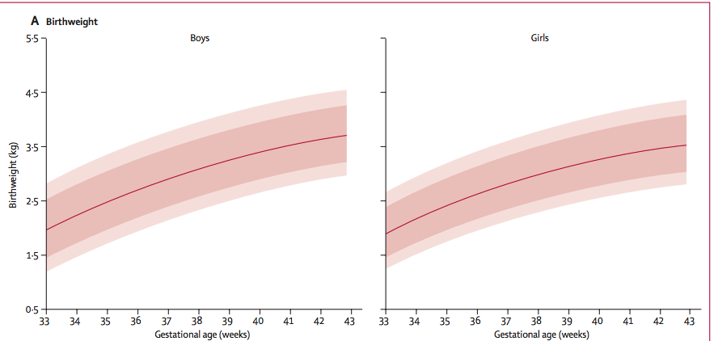

[Reference](https://intergrowth21.tghn.org/site_media/media/articles/newbornsize.pdf)

# Standardizing Normally distributed data

[figure not shown]

- [Birthweight z-scores for boys](https://intergrowth21.tghn.org/site_media/media/articles/INTERGROWTH-21st_Birth_Weight_Z_Scores_Boys_1.pdf)
- How does this relate to what you see on the previous slide?

# Simulating Normally distributed data in R

Suppose that we measured $1,000$ heights for young women:

```r
# students, rnorm() is important to know!
# this line of code generates 1,000 rows of data
# from a Normal distribution with
# the specified mean and sd.
heights.women <- rnorm(n = 1000, mean = 64.5, sd = 2.5)

# this line of code puts this variable into a data frame
heights.women <- data.frame(heights.women)
```

We can plot the histogram of the heights, and see that they roughly follow from a Normal distribution. The green curve is a Normal distribution, and the black curve is the density plot based on the actual data:

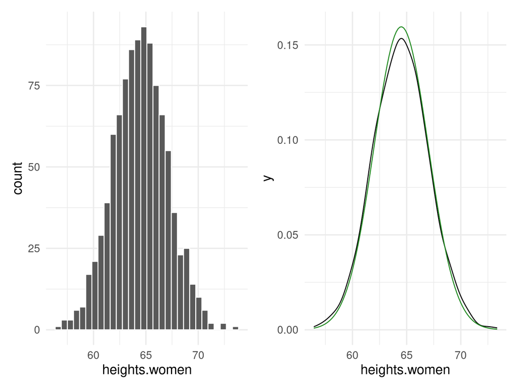

# Standardizing Normally distributed data in R

To standardize these data, we can apply the formula to compute the z-score:

```r
heights.women <- heights.women %>% mutate(mean = mean(heights.women),
                                          sd = sd(heights.women),
                                          z = (heights.women - mean)/sd)

head(heights.women)
```

```
##   heights.women     mean      sd            z
## 1      62.52607 64.47098 2.56336 -0.758734295
## 2      64.48976 64.47098 2.56336  0.007324184
## 3      63.64010 64.47098 2.56336 -0.324139640
## 4      61.14772 64.47098 2.56336 -1.296448229
## 5      65.28692 64.47098 2.56336  0.318306595
## 6      67.21041 64.47098 2.56336  1.068686960
```

What would the distribution of the standardized heights look like?

# Standardizing Normally distributed data in R

How are these plots different from the previous ones? Hint: look at the x axis.

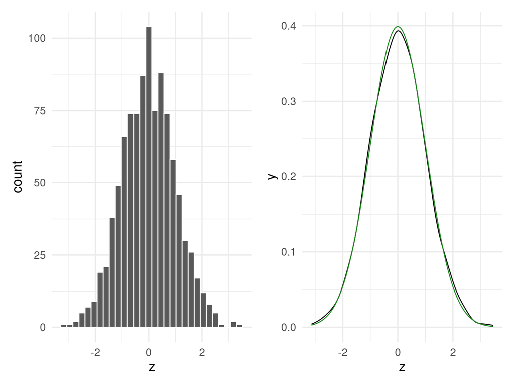

# Finding Normal probabilities

- A **cumulative probability** for a value x in a distribution is the proportion of observations in the distribution that lie below $x$
- Here is the cumulative probability for $x = 1.2$

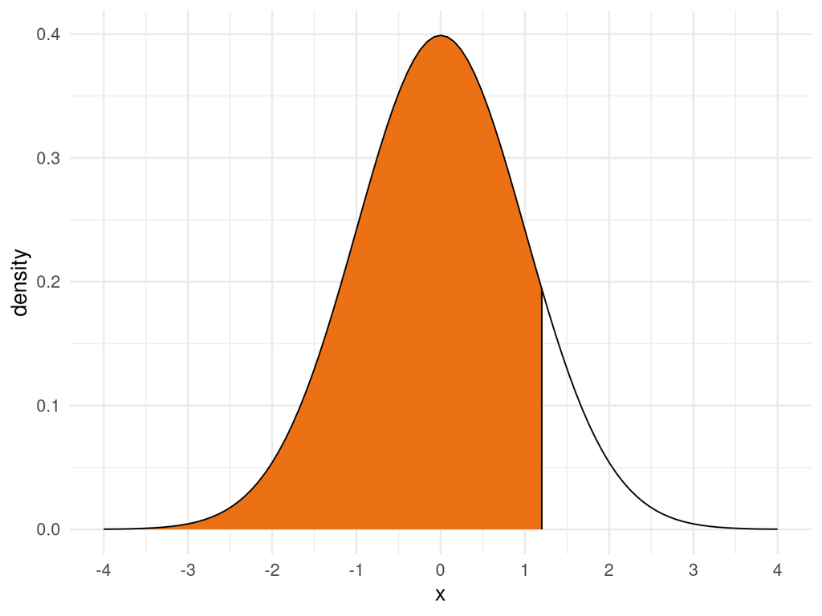

# Plot of Cumulative Standard Normal Distribution

- There are different ways to display a distribution such as the density and the cumulative distribution
- The cumulative distribution can be shown as a graph of the probability of being below a value on the x-axis

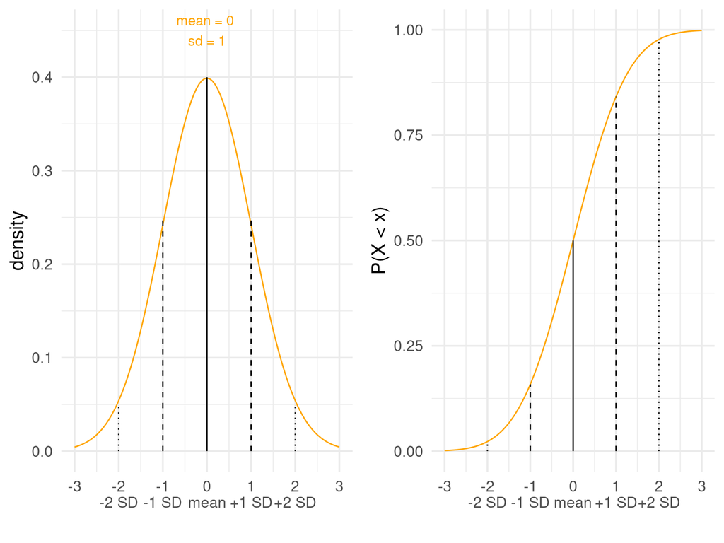

# Finding Normal probabilities

- Recall that 100% of the sample space for the random variable $X$ lies under its probability density function
- What is the amount of the area that is below $x = 1.2$?
- To answer this question we use the `pnorm()` function
  - Mnemonic: the **p** in `pnorm` stands for probability
  - The **norm** in `pnorm` stands for normal curve

```r
pnorm(q = 1.2, mean = 0, sd = 1)
```

```
## [1] 0.8849303
```

- This says that approximately 88% of the probability lies below $1.2$.

# Finding Normal probabilities

What if we wanted the reverse: $P(x>1.2)$?

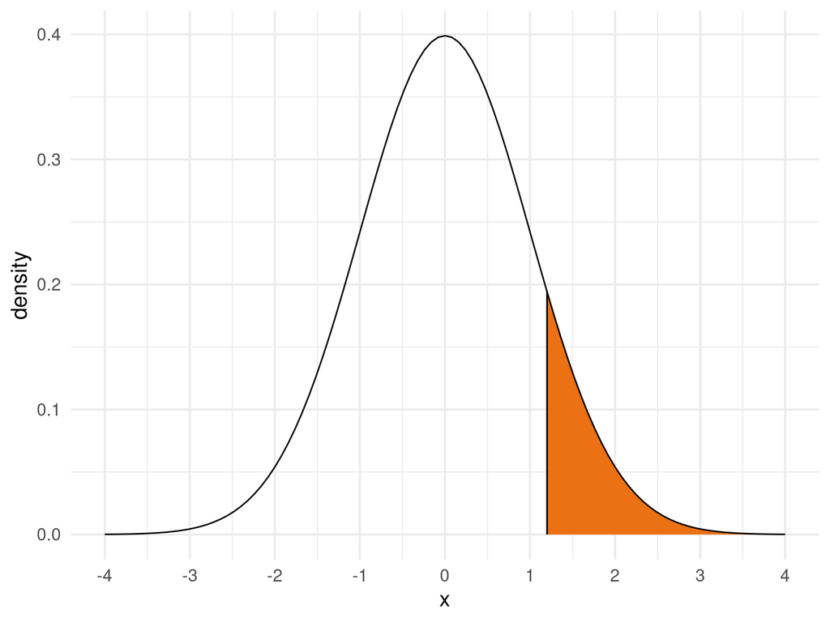

```r
1 - pnorm(q = 1.2, mean = 0, sd = 1)
```

```
## [1] 0.1150697
```

Alternatively:

```r
 pnorm(q = 1.2, mean = 0, sd = 1, lower.tail = F)
```

```
## [1] 0.1150697
```

So, $11.51$% of the data is above $x = 1.2$.

# Finding Normal probabilities

- What if we wanted two “tail” probabilities?
- $P(x < -1.2 \text{ or } x > 1.2)$

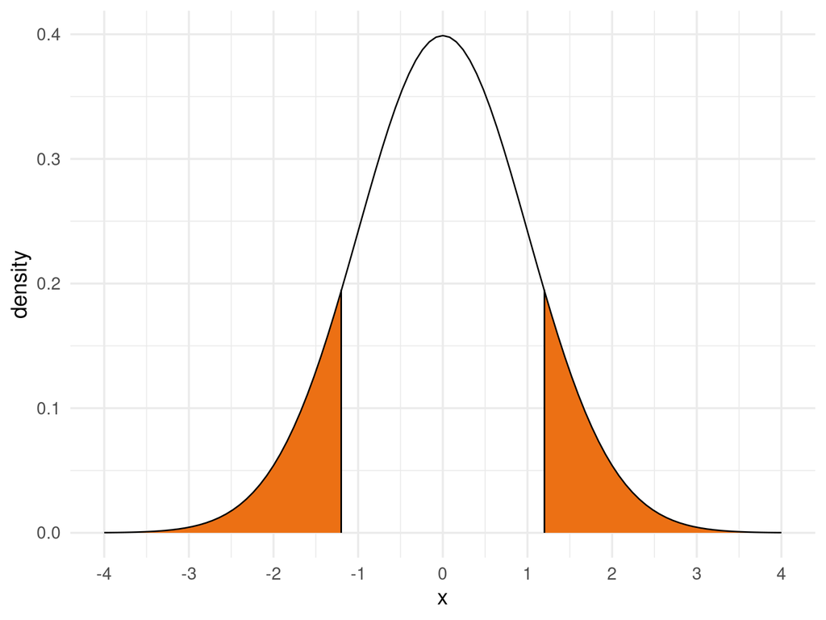

# Finding Normal probabilities

The trick: find one of the tails and then double the area because the distribution is symmetric:

```r
pnorm(q = -1.2, mean = 0, sd = 1)*2
```

```
## [1] 0.2301393
```

# Finding Normal probabilities

What if we wanted a range in the middle?: $P(-0.8 < x < 1.5)$?

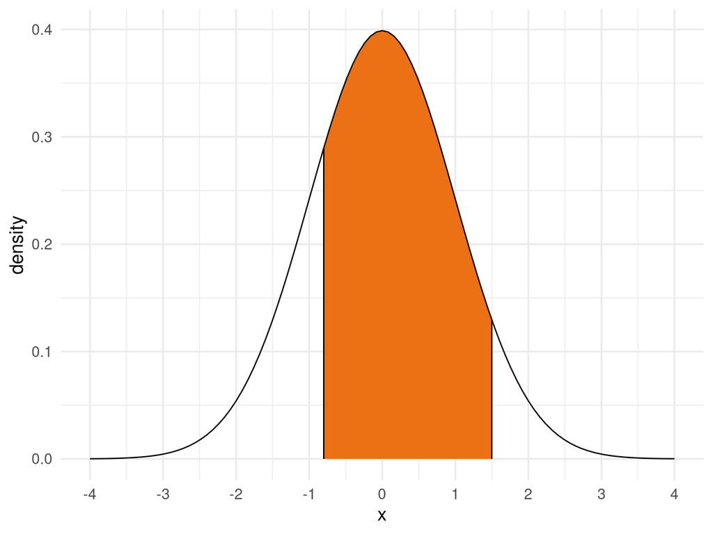

# Finding Normal probabilities

```r
# step 1: calculate the probability *below* the upper bound (x=1.5)
pnorm(q = 1.5, mean = 0, sd = 1)
```

```
## [1] 0.9331928
```

```r
# step 2: calculate the probability *below* the lower bound (x = -0.8)
pnorm(q = -0.8, mean = 0, sd = 1)
```

```
## [1] 0.2118554
```

```r
# step 3: take the difference between these probabilities to get what's left in
# the middle
pnorm(q = 1.5, mean = 0, sd = 1) - pnorm(q = -0.8, mean = 0, sd = 1)
```

```
## [1] 0.7213374
```

- Thus, $72.13$% of the data is in the range $-0.8 < x < 1.5$

# Your turn

- To diagnose osteoporosis, bone mineral density is measured
- The WHO criterion for osteoporosis is a BMD score below $-2.5$
- Women in their 70s have a much lower BMD than younger women
  - $BMD \sim N(-2, 1)$
- What proportion of these women have a BMD below the WHO cutoff?
  - Hint: you do not need to find a z-score!

```r
#to fill in during class
pnorm(q=-2.5, mean=-2, sd=1)
```

```
## [1] 0.3085375
```

# Recap of functions used

- `rnorm(n = 100, mean = 2, sd = 0.4)`, to generate Normally distributed data from the specified distribution
- `pnorm(q = 1.2, mean = 0, sd = 2)`, to calculate the cumulative probability below a given value